# Producing dynamic reports

Introduction

2022-06-15 13:56:20

# About this resource

## Introduction

Dynamic reports are data-driven documents that can be periodically updated as their underlying data changes.

This resource is a brief introduction to writing dynamic reports using [R](https://www.r-project.org/), [Rmarkdown](http://rmarkdown.rstudio.com), and [RStudio Cloud](https://rstudio.cloud). It is a two hour interactive session designed for those without previous programming experience who work in health and care. It gives a general introduction to the tools, and then some useful examples of frequently-met data-driven tasks. It is intended as a starting point for automating your report writing processes, with the aim of replacing, enhancing, or simplifying, manual report writing. The demonstration also covers ways of producing the report in a variety of formats including .pdf, .docx (Word format), and .html (webpage).

Some examples of routine reports that might be targets for re-working in a dynamic format:

- service-use reports (admission figures, bed utilisation)
- annual reports (public health annual reports)
- engagement and impact data (training, outreach)

### Who is this demo for?

This learning resource is intended for someone who:

- is currently spending lots of time manually updating reports in health, care, or housing
- **and** would like to reduce the time spent on this routine work over the medium-term (months)
- **and** has some time to spend reworking this report-writing process
- **and** are open to gaining some basic programming experience

Note too that it is a learning resource. You’ll need some time to read this introduction and get set for the training session, as well as for the two hour training session itself.

### What this demo is not

- it’s not a full introduction to working in R/Rmarkdown. R is deep (like most analytic platforms), and this demonstration covers only a little bit of the available functionality
- it’s not an introduction to everything that you might like to do with a data-driven report either. Instead, it covers some simple examples of common tasks as a way of familiarising you with a different workflow
- it’s definitely not a production-ready replacement for your existing reports. It’s a learning resource, rather than a pre-packed replacement
- it won’t teach you how to make real-time dashboards. If you need your report to update more than about once a day, you should consider building a dashboard instead (Power BI, R/Shiny, DASH)

## About dynamic reports

### Is it worth it for me?

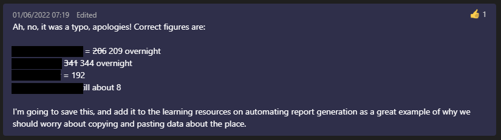

A recent personal example of a copy and paste error encountered while writing a short report. This would have been avoided if I’d been using a dynamic report.

That’s a metaphysical question, and not one that we can provide firm answers to! There are strengths and weaknesses of dynamic reports compared to traditionally-produced static reports:

#### Strengths

- **fidelity**. A dynamic report means no manual updating of text, graphs, and figures. No more copy and paste problems (see the Teams chat message above)
- **standardisation**. If you have lots of similar reports to write, this dynamic approach simplifies the process of making your reports look alike by applying a standard approach to formatting, analysis, and so on. This is a huge time-saver, especially true if you have lots of graphs to produce.
- **reproducibility**. If someone else looks at the source code for your report, they can see exactly how your figures are produced. That means that, when it’s time to hand over production of your report to a colleague, you won’t need to explain how to build the report. It’s all contained in the source-code.
- **efficiency**. Again assuming that everything works properly, updating a dynamic report with new data is much quicker than updating a comparable report by hand.

#### Weaknesses

- **set-up cost**. Particularly if you are new to this kind of work, writing a new dynamic report takes much longer than a traditional report. There’s plenty to learn, and it can be hard to find that time needed to learn, and to rework an established process.
- **errors**. While dynamic reports is a great way of avoiding minor errors from copying and pasting, it can introduce entirely new sources of error from reworking your analysis. Reports, particularly early on, need frequent careful checking to ensure that you haven’t swapped small frequent errors for large, subtle ones.
- **Information Governance and data protection concerns** about the platforms used to write these kinds of reports.
- **novelty**. Changing processes is often controversial, with a degree of resistance. For example, there’s a strong lock-in to the Microsoft Office suite (Word and Excel especially) for report writing. Suggesting something new can be daunting. Change management and QI methods might be helpful if you think this is likely to be a substantial concern for your project.

On balance, we think that dynamic reports have more advantages than disadvantages. But decisions about whether to automate a report will depend on the local factors in play. So that’s something that I’d be happy to discuss during (or after) the session.

## Getting started

### How does it work

We’ll use three tools to write the report. First, we’ll use the web service RStudio Cloud. This allows us to run R without installing any software or making any changes to our computer. Next, we’ll use the markup language Rmarkdown to add some text and images to our report. Finally, we’ll use the [R](https://www.r-project.org/) programming language to do some simple data handling, analysis, and visualisation.

RStudio Cloud is easy to set-up and free for small-scale work like this demo. This makes it by far the easiest way to get going from scratch if you’ve never worked with R before. Note that because it’s a web service, it requires you to upload your data to their servers, which might makes it unsuitable for production work in health and care owing to information governance concerns. That said, it’s easy to tranfer projects from RStudio Cloud to an installed version of R, so don’t worry that what you learn here will be tied to the cloud forever.

My suggestion would be not to try and use this demo to change your way of writing reports under pressure. There’s quite a lot to think about here, and you might need to spend a good bit of time working out how to adapt this demonstration to fit your report. Think of this as the start of a journey, rather than a destination.

### Joining instructions

You’ll need to do a little bit of preparation before the training session. I’d advise you to leave about 15 minutes to do this, so that we can make a prompt start to the session. If you’re new to RStudio Cloud, please follow the step-by-step instructions below. If you’re more experienced in this kind of work, you short-cut by signing-in to [RStudio Cloud](https://rstudio.cloud/), creating a new project from the Git Repository at https://github.com/bclarke-nes/Dynamic-report-demo, and then opening the demo.Rmd file. Otherwise:

1. Go to https://rstudio.cloud/
2. If you have an account, log in. Otherwise, create an account by selecting `Get started for free`, follow the steps, and then sign-in

[figure not shown]

4. Add a new project on RStudio Cloud by clicking `New Project >> New Project from a Git repository`. When prompted, enter the URL `https://github.com/bclarke-nes/Dynamic-report-demo`

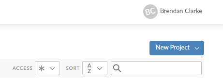

5. That will give you a new project containing the files needed for this demonstration:

[figure not shown]

6. Open the demo.Rmd file from the Files pane

## Aims and objectives

This session will:

- Give an introduction to why we should write dynamic reports
- What kinds of report are most suitable to automate
- Give a basic overview of R/Rmarkdown/RStudio Cloud, including basic data handling, simple data analysis, and drawing graphs
- Show how these functions can be integrated into a simple report format that will update as the underlying data changes

By the end of this session, the user should:

- Have gained a basic understanding of R, and how Rstudio Cloud and Rmarkdown can be used to generate reports
- Be familiar with the advantages and disadvantages of working in this way compared to traditional manual report writing in Word and Excel
- Be able to confidently navigate the parts of an Rmarkdown document
- Be able to recognise some simple R code, and with suitable assistance interpret it
- Be able to seek suitable help for their R code needs
- Produce and tweak simple descriptive statistical measures, and simple visualisations in R
- Be confident adding dynamic text elements to an Rmarkdown document